# Project 3: Data Visualisation

### Listing Category

```python
data.ListingCategory.value_counts()
```

```
Debt Consolidation    53180
Other                  9218
Home Improvement       6801
Business               5298
Auto                   2237
Household Expenses     1996
Medical/Dental         1522
Taxes                   885
Large Purchases         876
Wedding Loans           771
Vacation                768
Motorcycle              304
Student Use             274
Engagement Ring         217
Baby&Adoption           199
Cosmetic Procedure       91
Boat                     85
Green Loans              59
RV                       52
Not Available            20
Name: ListingCategory, dtype: int64
```

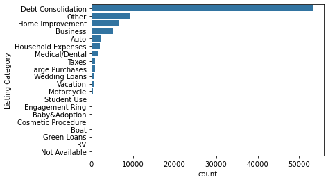

```python
#Graph of ListingCategory
categories = data['ListingCategory'].value_counts().index
sns.countplot(data = data, y = 'ListingCategory', color = color, order=categories)
plt.ylabel('Listing Category');
```

Debt consolidation triumphed by a colossal margin. It is the most well-liked loan kind offered by Prosper. It shouldn't really surprise you! Some noteworthy loan categories in the loans by Listing Categories include business and some personal loans.

### Prosper Rating

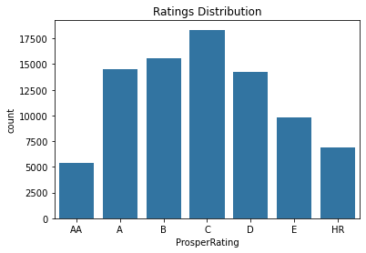

```python
#Plotting ProsperRating chart
color = sns.color_palette()[0]
sns.countplot(data = data, x = 'ProsperRating', color = color)
plt.title('Ratings Distribution')
plt.grid(False);
```

It appears that the majority of debtors have ratings between A and D.

## Bivariate Exploration

```python
#Numerical and categorical features
var_num = ['DebtToIncomeRatio', 'LoanOriginalAmount', 'StatedMonthlyIncome', 'BorrowerAPR']
var_cat = ['LoanStatus', 'IncomeRange', 'EmploymentStatus', 'Term', 'ProsperRating']
```

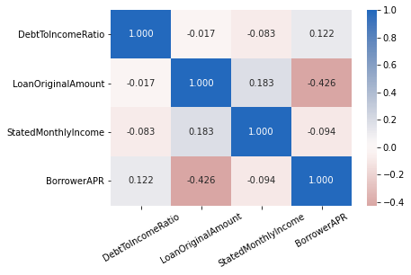

```python
#correlation plot
sns.heatmap(data[var_num].corr(), annot = True, fmt = '.3f',
           cmap = 'vlag_r', center=0)
plt.xticks(rotation = 30)
plt.show()
```

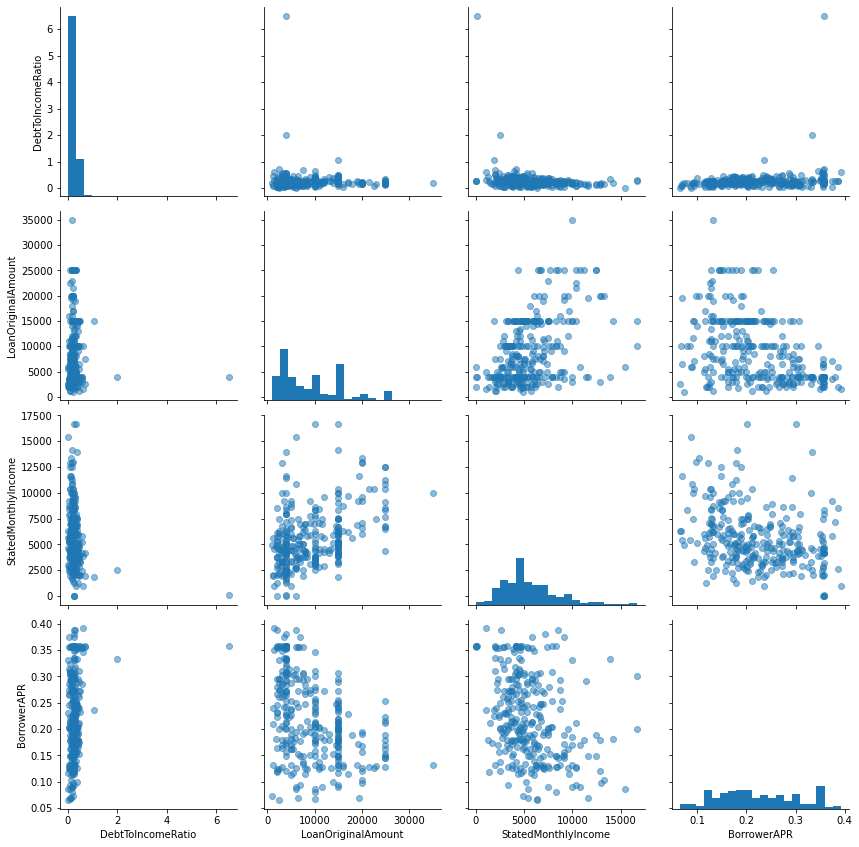

```python
# plot matrix: sample 400 loans so that plots are clearer
samples = np.random.choice(data.shape[0], 400, replace = False)
data_samp = data.reindex(samples)

# pair grid
p = sns.PairGrid(data = data_samp, vars = var_num, size = 3)
p = p.map_diag(plt.hist, bins = 20)
p.map_offdiag(plt.scatter, alpha = 1/2);
```

It appears that my prediction that the borrower APR and the initial loan amount were negatively correlated—that is, that the APR decreased as the loan amount increased—was accurate. The plot reveals a correlation coefficient of -0.426 between the two variables. Another adversely linked with stated monthly income is the debt-to-income ratio. We may also observe that the original loan amount and claimed monthly income have a 0.183 correlation, which indicates a favourable correlation. This makes logical because you should be able to get a bigger loan if your salary is larger.

### Relationship Between BorrowerAPR and Categorical variables (var_cat)

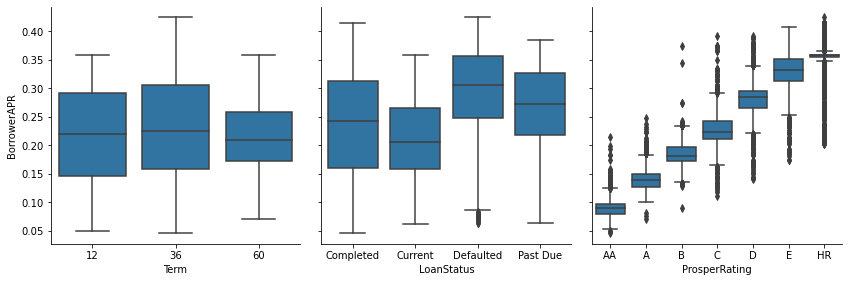

```python
#plot multiple figures with Pairgrid
g = sns.PairGrid(data = data, y_vars = ['BorrowerAPR'],
                x_vars = ['Term','LoanStatus','ProsperRating'], size = 4)
g.map(sns.boxplot, color = color);
plt.show();
```

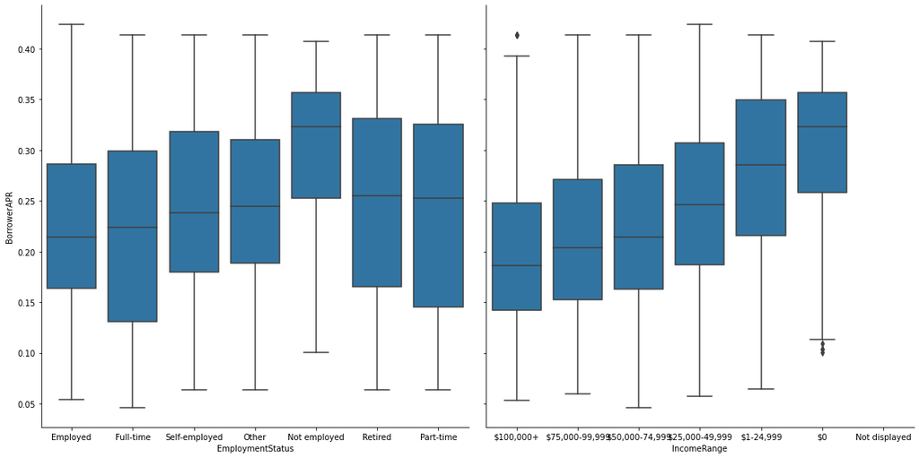

```python
#plot multiple figures with Pairgrid
g = sns.PairGrid(data = data, y_vars = ['BorrowerAPR'],
                x_vars = ['EmploymentStatus','IncomeRange'], size = 8)
g.map(sns.boxplot, color = color);
plt.show();
```

### Comparing LoanStatus with other Categorical Variables

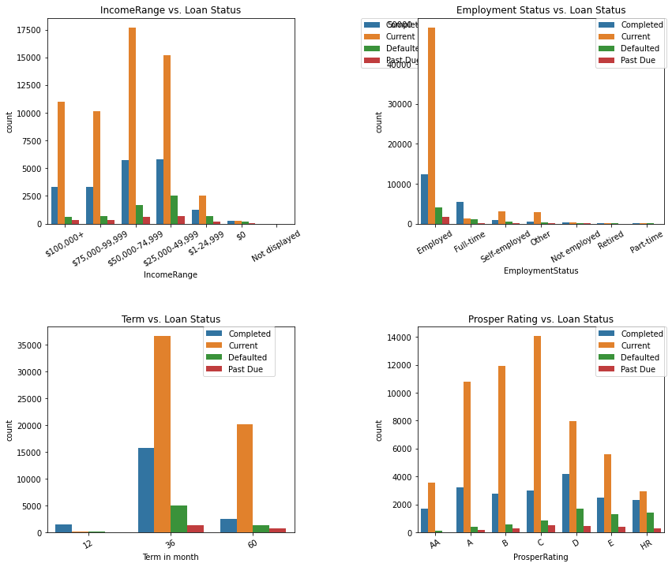

```python
#Graph of LoanStatus against other Categorical Variable
rcParams['figure.figsize'] = 14, 12

#subplot 1
plt.subplot(2,2,1)
sns.countplot(data = data, x = 'IncomeRange', hue = 'LoanStatus')
plt.legend(bbox_to_anchor=(1.27, 1),
           borderaxespad=0) # push the legend to the side
plt.title('IncomeRange vs. Loan Status')
plt.xticks(rotation = 30);


#subplot 2
plt.subplot(2,2,2)
sns.countplot(data = data, x = 'EmploymentStatus', hue = 'LoanStatus')
plt.xticks(rotation = 30)
plt.legend(bbox_to_anchor=(1.01, 1),
           borderaxespad=0)
plt.title('Employment Status vs. Loan Status');

#subplot 3
plt.subplot(2,2,3)
sns.countplot(data = data, x = 'Term', hue = 'LoanStatus')
plt.xticks(rotation = 30)
plt.legend(bbox_to_anchor=(0.92, 1),
           borderaxespad=0)
plt.xlabel('Term in month')
plt.title('Term vs. Loan Status');

#subplot 4
plt.subplot(2,2,4)
sns.countplot(data = data, x = 'ProsperRating', hue = 'LoanStatus')
plt.xticks(rotation = 30)
plt.legend(bbox_to_anchor=(1.01, 1),
           borderaxespad=0)
plt.title('Prosper Rating vs. Loan Status');

plt.subplots_adjust(wspace=0.50,
                    hspace=0.5)
```